# individual project

Ammar

2023-09-03

# 1 Qn 1a

## 1.1 Graph Structure

```
## Class 'igraph'  hidden list of 10
##  $ : num 161
##  $ : logi TRUE
##  $ : num [1:16335] 1 1 1 1 1 1 1 1 1 1 ...
##  $ : num [1:16335] 2 3 4 6 7 8 10 14 17 18 ...
##  $ : NULL
##  $ : NULL
##  $ : NULL
##  $ : NULL
##  $ :List of 4
##   ..$ : num [1:3] 1 0 1
##   ..$ : Named list()
##   ..$ :List of 5
##   .. ..$ id  : chr [1:161] "AGO" "ALB" "ARE" "ARG" ...
##   .. ..$ name: chr [1:161] "AGO" "ALB" "ARE" "ARG" ...
##   .. ..$ x   : num [1:161] 0.55 0.556 0.65 0.323 0.625 ...
##   .. ..$ y   : num [1:161] 0.438 0.729 0.63 0.287 0.723 ...
##   .. ..$ z   : num [1:161] 0.5 0.5 0.5 0.5 0.5 0.5 0.5 0.5 0.5 0.5 ...
##   ..$ :List of 1
##   .. ..$ weight: num [1:16335] 1197 163 148 777 11840 ...
##  $ :<environment: 0x11683c278>
```

## 1.2 Graph Level Attributes

**Number of Nodes:** 161

**Graph Density:** 0.6341227

**Graph Diameter:** 558.699

**Size of largest Component:** 161

**Global Transitivity:** 0.8416801

**Average Transitivity** 0.8707874

**Size of Largest Clique:** 81

**Diameter of Graph:** 558.699

There are 161 countries represented in the trade network and a total of 16,335 trade relationships (edges) in the network, indicating a **relatively dense** network.The graph density is approximately 0.634, which suggests that about 63.4% of all possible trade relationships between countries are present. This indicates a **relatively connected** network. The diameter of the graph is 558.699. This represents the longest shortest path between any two countries in the trade network, which is a measure of the network’s overall size.

The entire network forms a single connected component with all 161 countries, indicating that there are **no isolated subnetworks**.The global transitivity (clustering coefficient) is approximately 0.842, suggesting that there is a **significant tendency** for groups of countries to engage in trade with one another, forming clusters or communities within the network. The average transitivity is approximately 0.871, which is similar to the global transitivity. This further confirms a **high degree of clustering** within the network. The largest clique in the network consists of 81 countries. This indicates the **presence of a highly interconnected group of countries** that trade extensively with each other.

## 1.3 Vertex Attributes

Table 1.1: Vertex Attributes

|  | degree | closeness | betweenness | transitivity | eigen_centrality |
| --- | --- | --- | --- | --- | --- |
|  | Min. : 25.0 | Min. :0.000019 | Min. :0.000000 | Min. :0.7591 | Min. :0.0000033 |
|  | 1st Qu.:158.0 | 1st Qu.:0.000814 | 1st Qu.:0.000000 | 1st Qu.:0.8075 | 1st Qu.:0.0004253 |
|  | Median :212.0 | Median :0.000901 | Median :0.005503 | Median :0.8749 | Median :0.0024244 |
|  | Mean :202.9 | Mean :0.000826 | Mean :0.023705 | Mean :0.8708 | Mean :0.0397474 |
|  | 3rd Qu.:263.0 | 3rd Qu.:0.000927 | 3rd Qu.:0.029756 | 3rd Qu.:0.9291 | 3rd Qu.:0.0206742 |
|  | Max. :301.0 | Max. :0.001133 | Max. :0.236006 | Max. :0.9933 | Max. :1.0000000 |
|  | NA | NA’s :19 | NA | NA | NA |

### 1.3.1 Betweenness and Transitivity

**Betweenness Centrality:**

- Betweenness centrality measures how often a country acts as a bridge or intermediary in trade relationships between other countries. The values range from 0 to a maximum of 0.236006, indicating variations in the importance of countries in facilitating trade routes.
- The values are still pretty much quite low, indicating that most countries do not rely on thir party channels to do trade with a country of interest.

**Transitivity:**

- The values range from 0.7591 to 0.9933, suggesting that many countries form tightly interconnected groups in trade networks.

### 1.3.2 Closeness Distribution

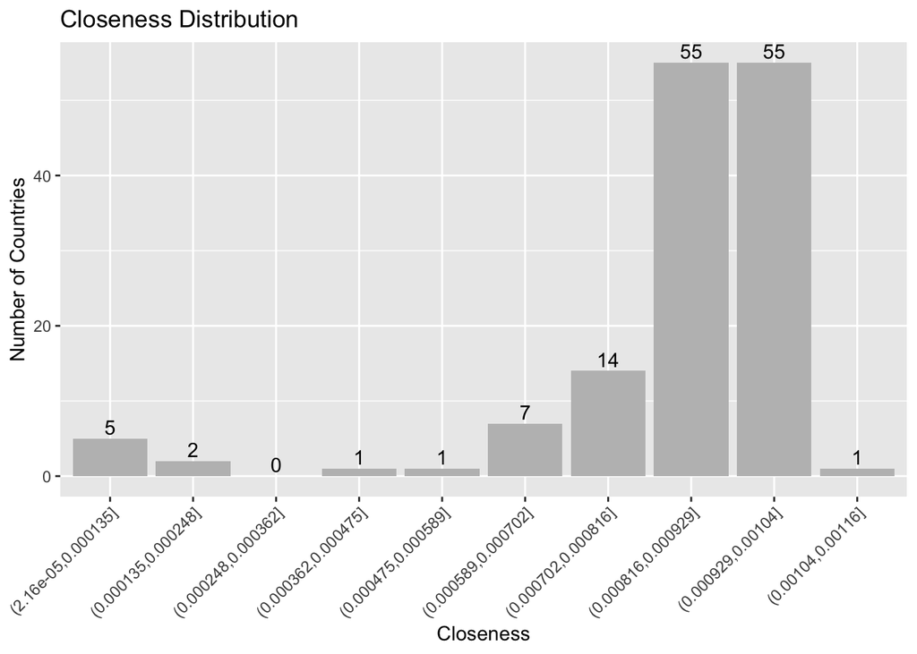

Figure 1.1: Filtered Closeness Distribution

Overall, the closeness centrality values are generally very low, with a maximum of no more than 0.00116. Nonetheless, here are some findings:

Based on Figure 1.1 over 120 out of 161 countries have closeness centrality $\ge$ 0.000702, which is relatively high.

- The presence of 19 countries with missing closeness centrality values suggests that these countries might only accept imports and not do exports.

### 1.3.3 Eigen Centrality

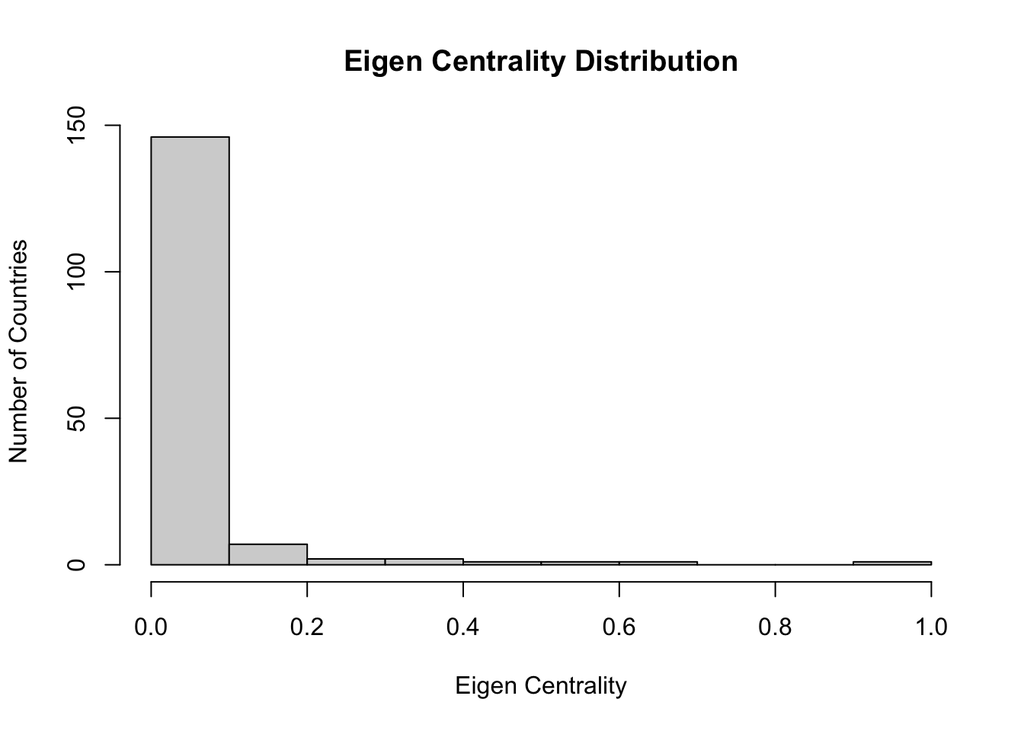

Figure 1.2: Eigen Centrality

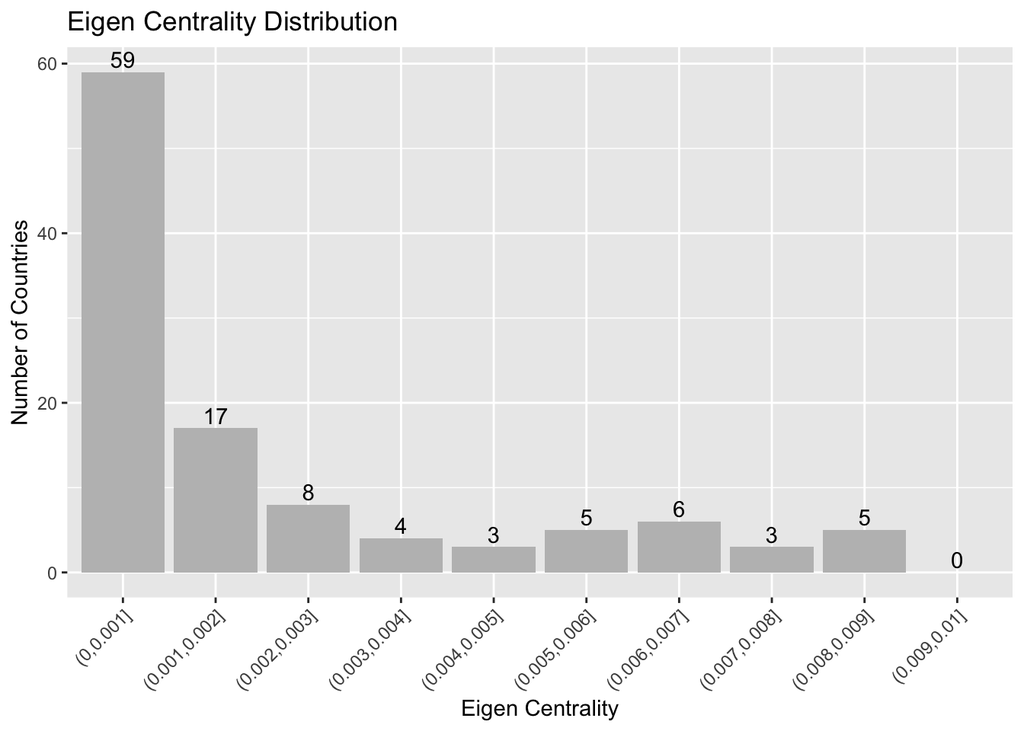

Figure 1.3: subset of Eigen Centrality

Based on Figure 1.3 59 countries have eigen centrality values of between 0 to 0.001, and this forms the majority of the countries.

- Countries with eigen centrality values in this range are likely to be less influential in the global trade network. They may have limited trade connections or trade relationships that are not strongly influential on a global scale.
- These countries may not play a significant role in shaping global trade patterns. They might have relatively small trade volumes or trade primarily with a limited set of partners.
- Their influence on the network’s structure and dynamics is relatively low, and they are less likely to act as intermediaries in trade routes.

The second largest group of countries, approximately 17, have eigen centrality values of between 0.001 to 0.002.

- Countries falling within this range have a somewhat more significant influence on the trade network compared to those in the lower eigen centrality range. They may have more extensive trade connections and contribute to regional trade patterns.
- These countries may play key roles in regional trade blocs or economic partnerships, influencing trade dynamics within their respective regions.
- While not among the most influential in the global trade network, they have a moderate degree of influence on the network’s structure and connectivity.

There are very few countries with relatively high eigen centralities, meaning in the year 2000, there was a lack of trade power-hubs.

### 1.3.4 Degree Distribution

#### 1.3.4.1 Exports Distribution

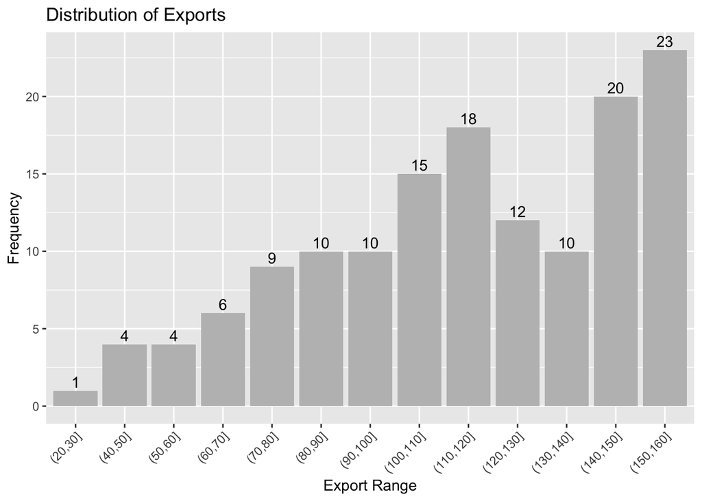

Figure 1.4: Out Degree Distribution

- The export distribution histogram is generally left-skewed. This means that there are more countries with higher export counts (toward the right side of the distribution) than with lower export counts (toward the left side of the distribution).
- If we look at the distribution from left to right, we can observe that the frequency counts generally decrease as we move from high export count ranges to low export count ranges.

#### 1.3.4.2 Imports Distribution

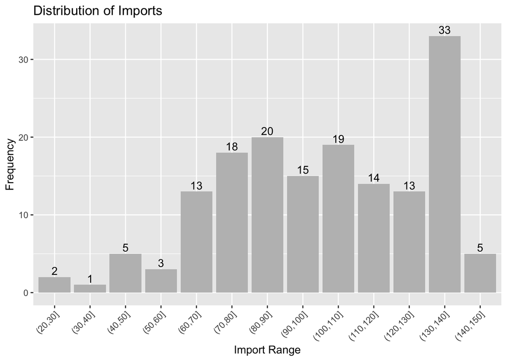

Figure 1.5: In Degree Distribution

Brief description of the degree distribution:

Based on Figure 1.5 and Figure 1.4 We can understand that most countries are generally well connected. However, we should explore the distribution of export power and import power of each country We can define export and import power as follows:

$export_power = \displaystyle \frac{exports}{exports + imports}$

$import_power = \displaystyle \frac{imports}{exports + imports}$

Let us first look at it the export/ import power from a **degree** perspective

Table 1.2: Export and Import Power Summary

|  | country | export_cnt | import_cnt | export_degree_power | import_degree_power |
| --- | --- | --- | --- | --- | --- |
|  | Length:161 | Min. : 0.0 | Min. : 25.0 | Min. : 0.00 | Min. : 35.90 |
|  | Class :character | 1st Qu.: 78.0 | 1st Qu.: 80.0 | 1st Qu.:47.90 | 1st Qu.: 46.50 |
|  | Mode :character | Median :111.0 | Median :102.0 | Median :52.10 | Median : 47.90 |
|  | NA | Mean :101.5 | Mean :101.5 | Mean :45.69 | Mean : 54.31 |
|  | NA | 3rd Qu.:142.0 | 3rd Qu.:130.0 | 3rd Qu.:53.50 | 3rd Qu.: 52.10 |
|  | NA | Max. :160.0 | Max. :141.0 | Max. :64.10 | Max. :100.00 |

#### 1.3.4.3 Export Power Degree Distribution

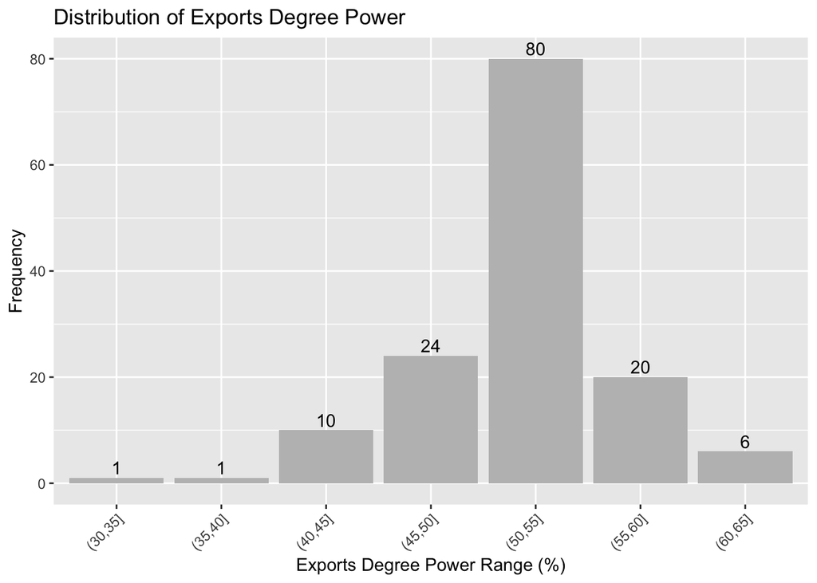

Figure 1.6: Out Degree Power Distribution

#### 1.3.4.4 Import Power Degree Distribution

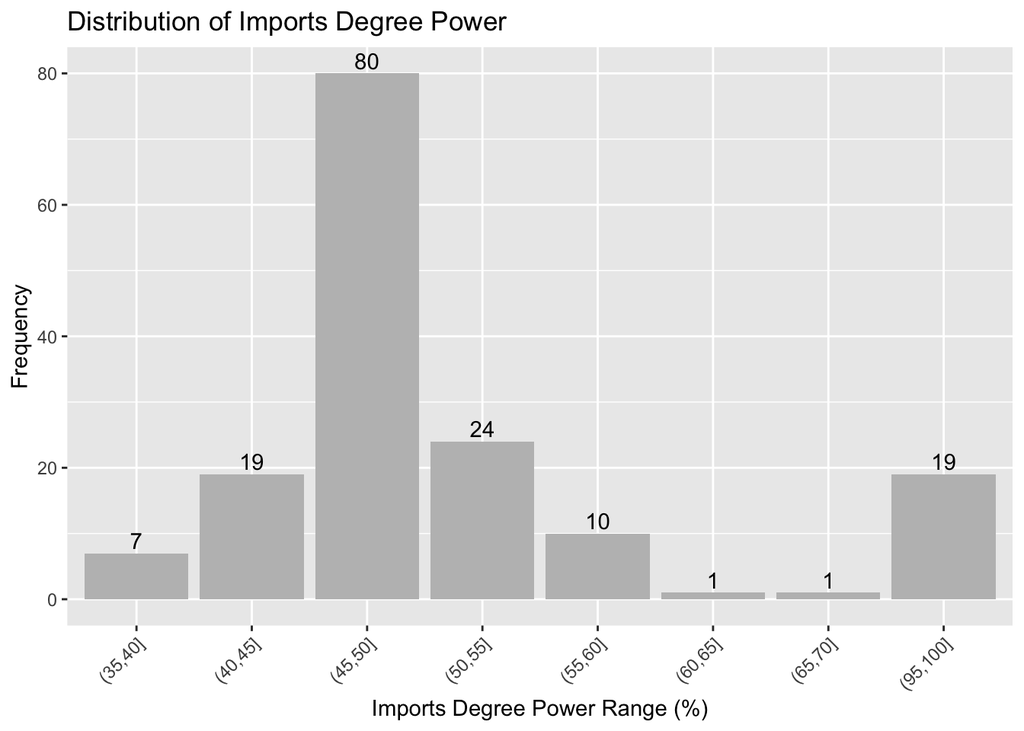

Figure 1.7: In Degree Power Distribution

From Fig 1.6 and Fig 1.7, we can observe that most countries generally engage in more exports than import

- 106 countries have export power of $\ge$ 50%
- 106 countries have import power of $\le$ 50%

This shows that in general, countries generally have more export ties than import ties in the year 2000.

Now, let us take a look at the export/ import power from a **trade volume** perspective

### 1.3.5 Trade Volume vs Ties

Table 1.3: Export and Import Volume Summary

|  | country | total_export_volume | export_ties | total_import_volume | import_ties | export_vol_power | import_vol_power | ave_export_vol | ave_import_vol |
| --- | --- | --- | --- | --- | --- | --- | --- | --- | --- |
|  | Length:161 | Min. :0.000e+00 | Min. : 0.0 | Min. : 11708 | Min. : 25.0 | Min. : 0.00 | Min. : 0.00 | Min. : 0 | Min. : 260 |
|  | Class :character | 1st Qu.:6.029e+05 | 1st Qu.: 78.0 | 1st Qu.: 564023 | 1st Qu.: 80.0 | 1st Qu.:39.80 | 1st Qu.:30.70 | 1st Qu.: 7121 | 1st Qu.: 6688 |
|  | Mode :character | Median :2.869e+06 | Median :111.0 | Median : 3057867 | Median :102.0 | Median :51.20 | Median :45.00 | Median : 28578 | Median : 32540 |
|  | NA | Mean :3.649e+07 | Mean :101.5 | Mean : 36491004 | Mean :101.5 | Mean :47.77 | Mean :40.43 | Mean : 239977 | Mean : 270385 |
|  | NA | 3rd Qu.:1.627e+07 | 3rd Qu.:142.0 | 3rd Qu.: 24776723 | 3rd Qu.:130.0 | 3rd Qu.:62.00 | 3rd Qu.:54.20 | 3rd Qu.: 146595 | 3rd Qu.: 198854 |
|  | NA | Max. :1.172e+09 | Max. :160.0 | Max. :777795851 | Max. :141.0 | Max. :96.50 | Max. :80.10 | Max. :7324712 | Max. :5516283 |

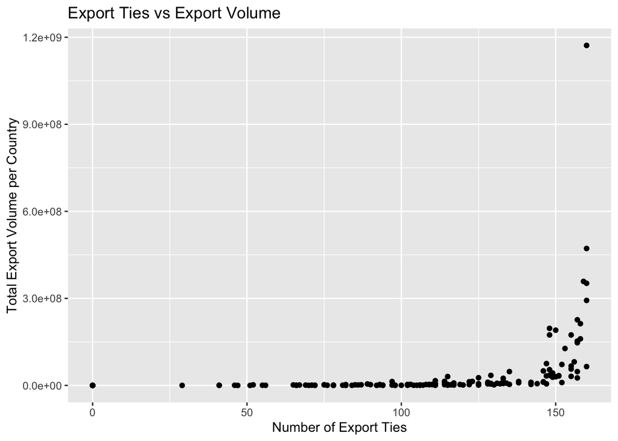

Figure 1.8: Export Ties vs Volume

Since the maximum export volume is significantly larger than the minimum export volume, let us try applying log transformation to the export volume, to minimise the absolute difference in export volumes, and try to observe any trends.

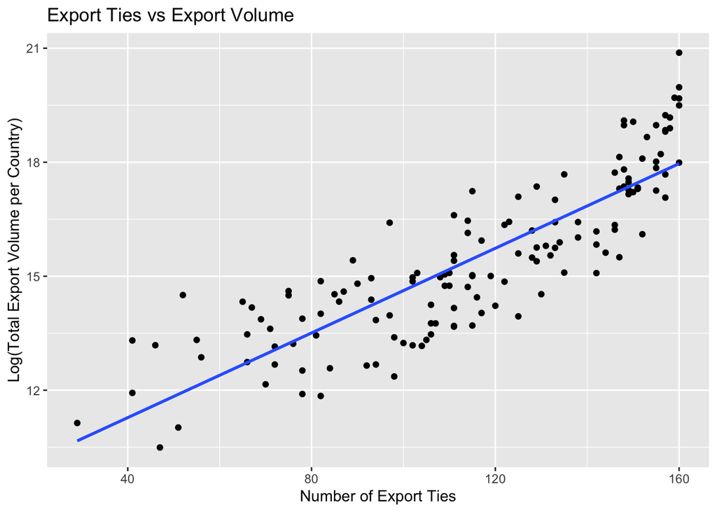

Figure 1.9: Log transformed export volume against Export Ties

**Slope Coefficient of Best Fit line:** 0.0803683

These are some deductions that can be made:

**Positive Linear Relationship:** The log-transformed total export volume and the number of export ties show a positive linear relationship. As the number of export ties increases, the log-transformed export volume tends to increase as well. This suggests that there is a tendency for countries with more export ties to have higher export volumes.

**Magnitude of Change:** Since the dependent variable (total_export_volume) is log-transformed, we can interpret the coefficient as a percentage change in the original export volume. Specifically, a one-unit increase in export ties is associated with an estimated increase of approximately 8.04% in the original export volume (not on the log scale).

**Exponential Growth in Export Volume:** The log transformation is often used to stabilize variance when dealing with data that spans several orders of magnitude. In this case, it helps reveal that the growth in export volume is not linear but rather exponential. As countries establish more export ties, their export volumes tend to grow exponentially.

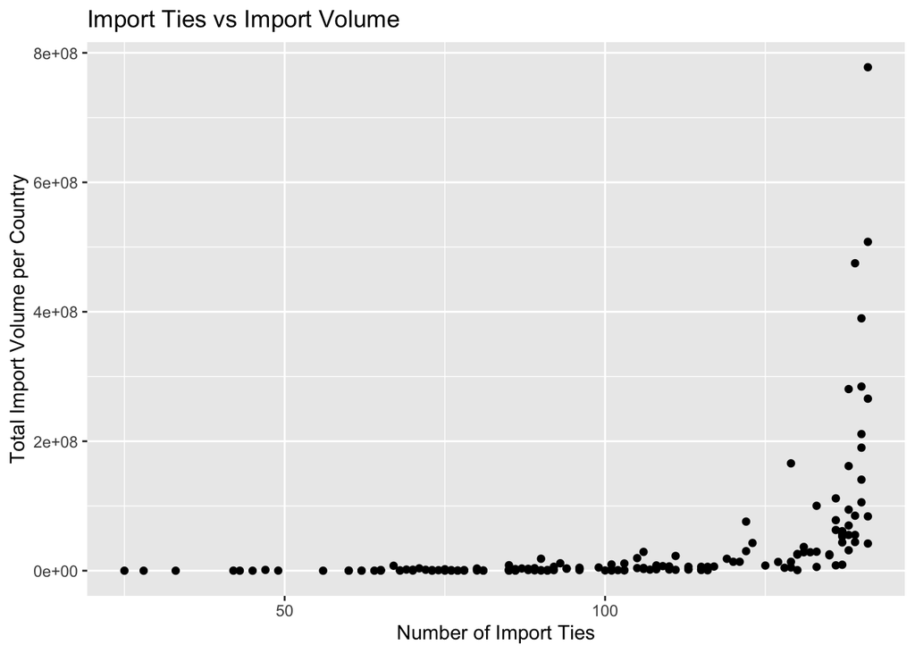

Figure 1.10: Import Ties vs Volume

Similarly, the maximum import volume is significantly larger than the minimum import volume, let us try applying log transformation to the import volume, to minimise the absolute difference in import volumes, and try to observe any trends.

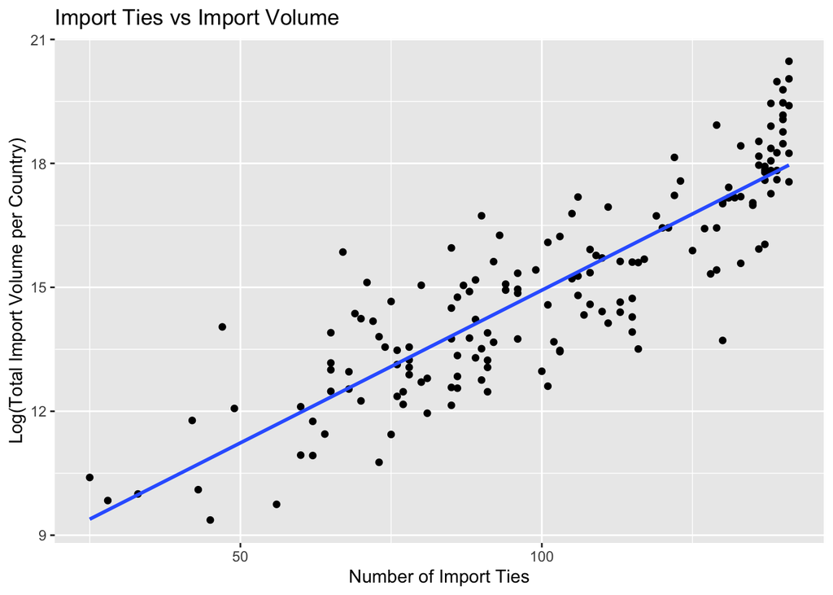

Figure 1.11: Log transformed import volume against Import Ties

**Slope Coefficient of Best Fit line:** 0.1065993

**Positive Linear Relationship:** The log-transformed total import volume and the number of import ties show a positive linear relationship. As the number of import ties increases, the log-transformed import volume tends to increase as well. This suggests that there is a tendency for countries with more import ties to have higher import volumes.

**Magnitude of Change:** Since the dependent variable (total_import_volume) is log-transformed, we can interpret the coefficient as a percentage change in the original import volume. Specifically, a one-unit increase in import ties is associated with an estimated increase of approximately 10.66% in the original import volume (not on the log scale).

**Note: This is greater than the estimated increase in original export volume with a one-unit increase in export ties.**

**Exponential Growth in Export Volume:** As countries establish more import ties, their import volumes tend to grow exponentially.

### 1.3.6 Trade Volume Power

Recap:

$export_power = \displaystyle \frac{exports}{exports + imports}$

$import_power = \displaystyle \frac{imports}{exports + imports}$

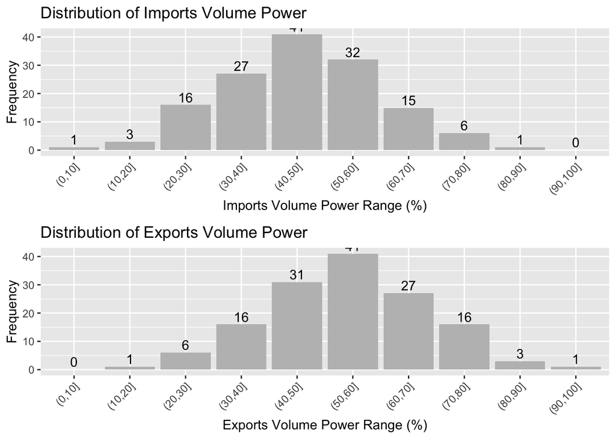

Figure 1.12: Distribution of Imports/ Exports Volume Power

In General, more countries have a higher percentage of exports than imports.

# 2 Qn 1b

```
## Class 'igraph'  hidden list of 10
##  $ : num 161
##  $ : logi TRUE
##  $ : num [1:16335] 1 1 1 1 1 1 1 1 1 1 ...
##  $ : num [1:16335] 2 3 4 6 7 8 10 14 17 18 ...
##  $ : NULL
##  $ : NULL
##  $ : NULL
##  $ : NULL
##  $ :List of 4
##   ..$ : num [1:3] 1 0 1
##   ..$ : Named list()
##   ..$ :List of 5
##   .. ..$ id  : chr [1:161] "AGO" "ALB" "ARE" "ARG" ...
##   .. ..$ name: chr [1:161] "AGO" "ALB" "ARE" "ARG" ...
##   .. ..$ x   : num [1:161] 0.55 0.556 0.65 0.323 0.625 ...
##   .. ..$ y   : num [1:161] 0.438 0.729 0.63 0.287 0.723 ...
##   .. ..$ z   : num [1:161] 0.5 0.5 0.5 0.5 0.5 0.5 0.5 0.5 0.5 0.5 ...
##   ..$ :List of 1
##   .. ..$ weight: num [1:16335] 1197 163 148 777 11840 ...
##  $ :<environment: 0x126ad2ff8>
```